# Spatial Data Analysis (450:320)

Class 14

## Today

**Geometry confirmation**

## Run some examples together

Query some data

```r
library(dplyr)
library(osmdata) # has to install first

q <- opq(bbox = st_bbox(
    c(xmin = -74.448598, xmax = -74.429830,
      ymax = 40.532277, ymin = 40.518258), crs = st_crs(4326)))

# Campus
liv_campus <- q %>%
    add_osm_feature(key = "amenity", value = "university") %>%
    osmdata_sf() %>% `[[`('osm_polygons') %>%
    filter(name == "Rutgers Livingston Campus") %>% select(name)

# Streets
streets <- q %>%
    add_osm_feature(key = 'highway') %>%
    osmdata_sf() %>% `[[`('osm_lines') %>%
    filter(!is.na(name)) %>% select(name)

# Trees
trees <- q %>%
    add_osm_feature(key = c('natural')) %>%
    osmdata_sf() %>% `[[`('osm_points') %>% select()

plot(liv_campus$geometry)
plot(streets$geometry, add = TRUE, col = "brown")
plot(trees$geometry, add = TRUE, col = "darkgreen")
```

## Run some examples together

```r
# Get the trees within Livingston Campus
## st_within(x, y), check every geometry in x one by one if it is in y or not.
ids_tl <- st_within(trees, liv_campus)
# st_contains
ids_lt <- st_contains(liv_campus, trees)
# More general st_intersects
ids_ints_lt <- st_intersects(liv_campus, trees)
# Observe the difference
ids_ints_tl <- st_intersects(trees, liv_campus)
```

**Task: use whatever function, continue to get the trees within Livingston Campus.**

Hint: think about how to get the row index to subset `trees`.

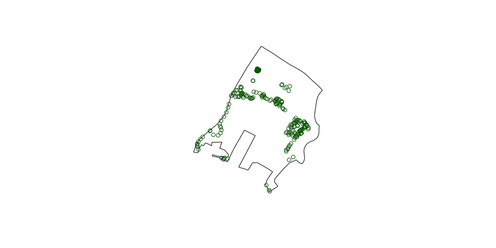

## Practice 1

Get the data:

```r
# Prepare data
library(rnaturalearth)
cnts_africa <- ne_countries(
    continent = 'africa',
    returnclass = 'sf') %>% dplyr::select(name)
dt_url <- 'https://sselp.github.io/sdawr//hyenas_occurrence.csv'
occurrence <- read.csv(dt_url, stringsAsFactors = F) %>%
  dplyr::select(gbifID, decimalLatitude, decimalLongitude) %>%
  st_as_sf(coords = c('decimalLongitude', 'decimalLatitude'), crs = 4326)

plot(cnts_africa %>% st_geometry())
plot(occurrence$geometry, add = T, pch = 20, col = 'purple')
```

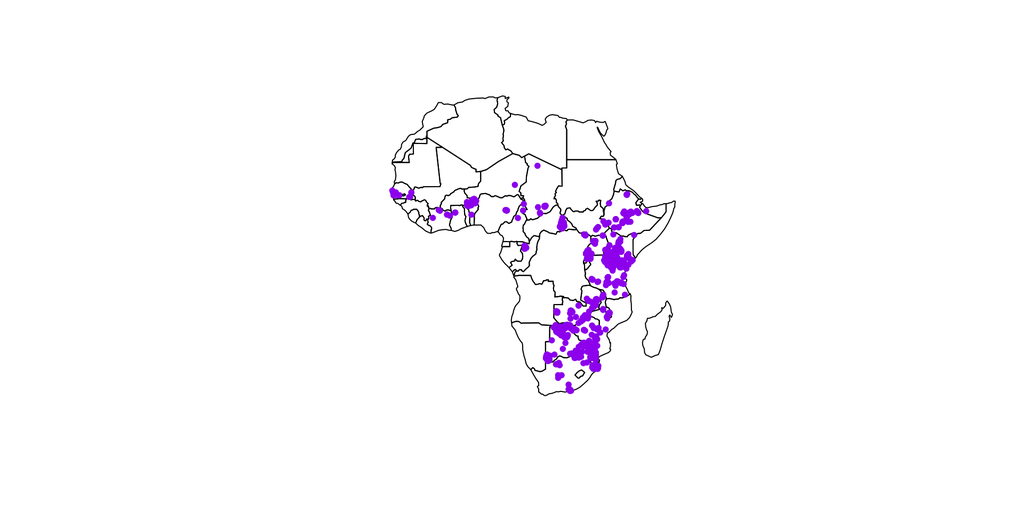

## Practice 1

- Manipulate `cnts_africa` and `occurrence` to get countries that have more than 100 occurrences. Hint: `st_join`, `group_by`.
- Get the countries that touch with Tanzania. Hint: `st_touches`.
- Get the occurrence inside of Tanzania (`st_intersects`, `st_contains` or `st_within`).
- Get the occurrence outside of Tanzania (`st_disjoint`).

## Other geometry operations

- `st_nearest_feature`

```r
# st_nearest_feature(x, y) returns the index of the feature in y that is
# closest to each feature in x
ids <- st_nearest_feature(streets, trees)
# For example, the first ids is 343. What does this mean?

plot(streets[1, ]$geometry)
plot(trees$geometry, add = T, pch = 20, col = "darkgreen")
plot(trees[343, ]$geometry, add = T, pch = 20, col = "purple")
```

**Task: plot the 10th street and the nearest tree to it.**

## More operations

- `st_convex_hull` (smallest convex polygon)
- `st_crop` (cropped by the bbox actually)

```r
# Note we need to use st_union first for multiple points
ch_trees <- st_convex_hull(st_union(trees))

plot(trees$geometry)
plot(ch_trees, add = TRUE, border = "brown")

# Observe the plot
streets_crop <- st_crop(streets, liv_campus)

plot(liv_campus$geometry)
plot(streets$geometry, add = TRUE, col = "pink")
plot(streets_crop$geometry, add = TRUE, col = "blue")
```

## Homework

- Finish homework [“Interactive Piscataway Map”](https://lei-song.shinyapps.io/SDA320-homework/#section-interactive-piscataway-map). And share your knitted html file in Google chat.
- Read this paper: [A Cappadocian Speculation](https://sselp.github.io/sdawr/231039a0.pdf) to have a sense of how spatial relations hidden in simple settings can be uncovered through geographic thinking.